# Road traffic injuries: data and regression models

# Data

First let’s look at the basic log-log relationship between number of cyclist injuries and distance travelled (over 11 years and across 148 areas).

These plots are descriptive: we’re expecting to see a positive correlation, i.e. the more cycling there is, the more injuries to cyclists there are.

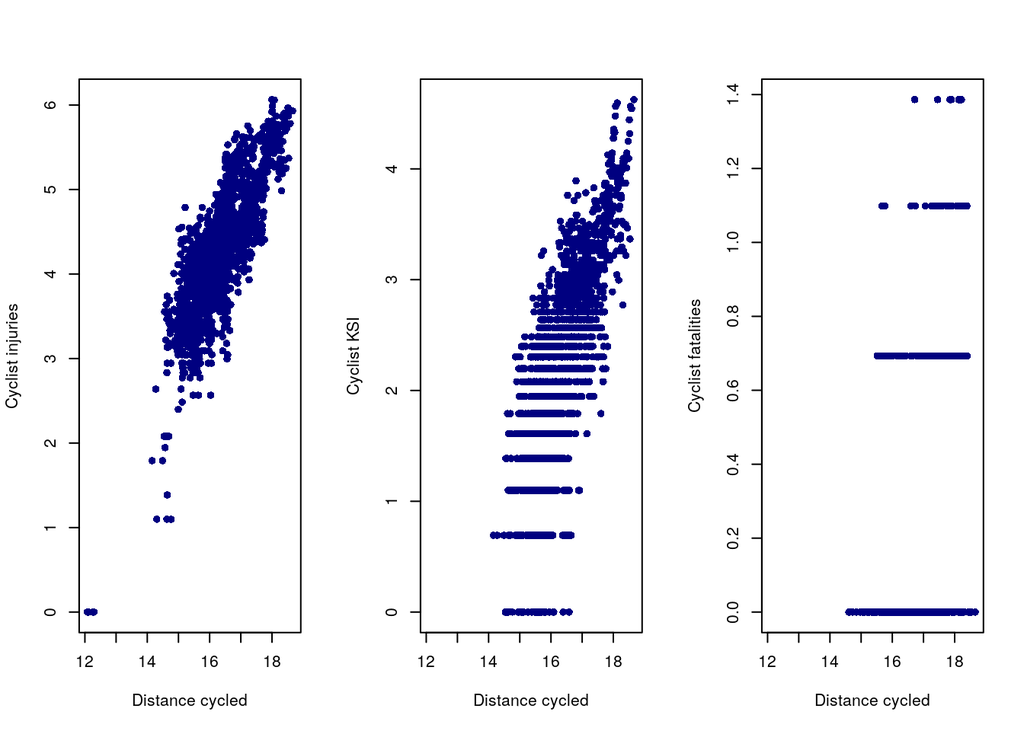

And now let’s look at the difference between all the areas and the urban areas (in pink, defined as the areas with >99% of the population living in an urban area (city, town or minor conurbation) in the 2011 census).

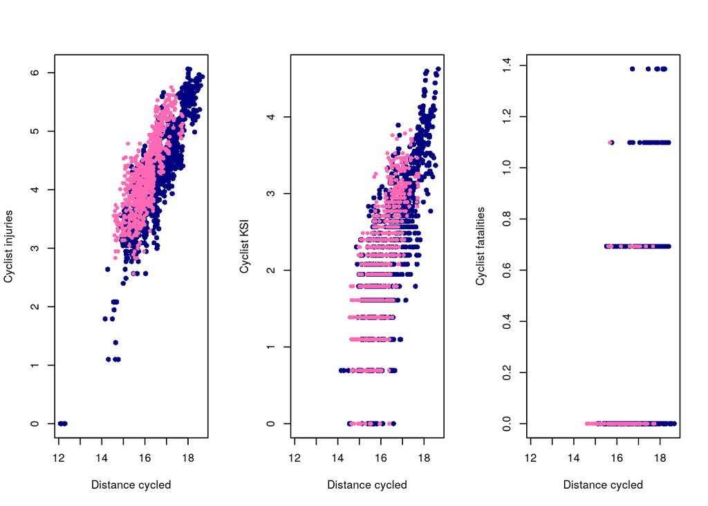

So is it possible that we get the safety-in-numbers results as a result of having all high-density (urban) areas having lower levels of cycling? I.e., all the high-cycling places are rural and sparse? Yes: there is a relationship between total road length and total cycling, with urban areas having the shortest total road length (excepting the Isles of Scilly) and not the most total cycling.

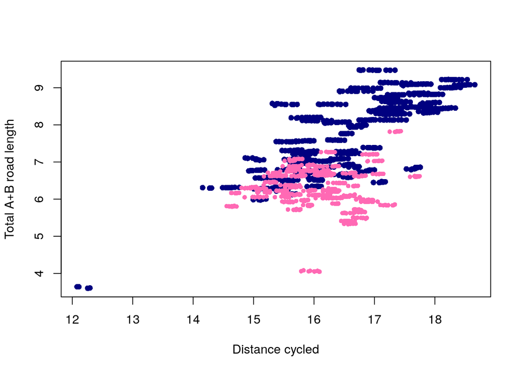

Now let’s look at the rates (the numbers per distance travelled).

These plots should be more diagnostic: we should expect to see a negative correlation if the more cycling there is, the fewer injuries there are per cyclist.

Note that there are fewer events for serious injuries and fewer still fatalities. This results in the straight diagonal lines, and indicate that the definition of rate is not useful here.

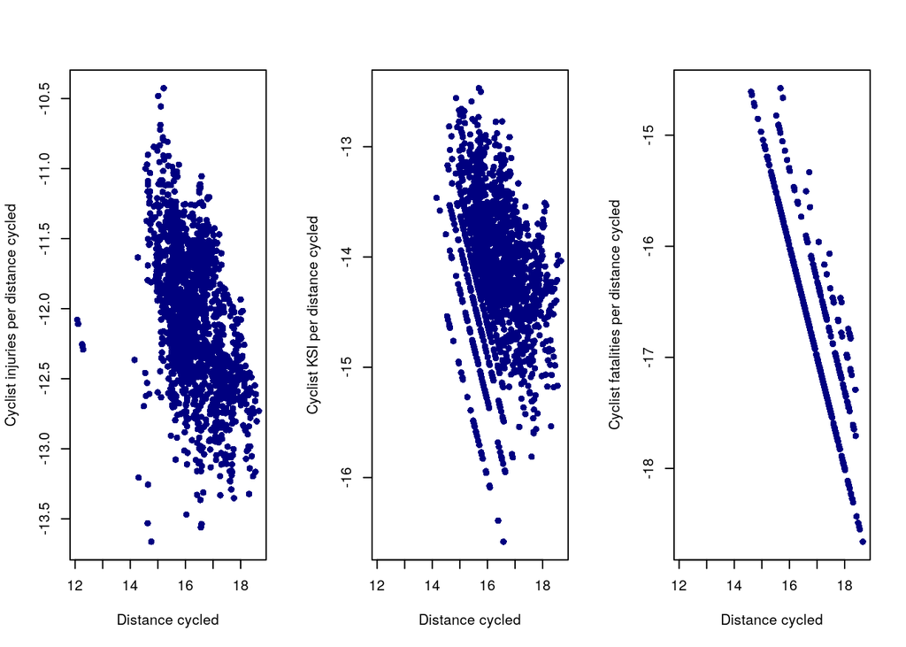

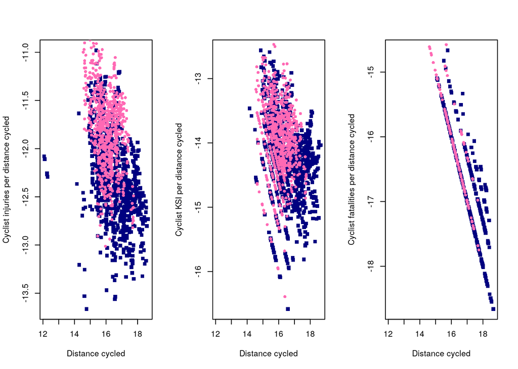

# Analysis : numbers

### Total travel distance only as a predictor, for all, urban and rural, for all, ksi, and fatal.

```
##                  all     urban     rural
## injuries   0.7693354 0.8533565 0.9531445
## KSI        0.8962531 1.0143103 1.0188246
## fatalities 1.1076575 1.2367091 1.0171415
```

### Population only as a predictor, for all, urban and rural, for all, ksi, and fatal.

```
##                  all     urban     rural
## injuries   0.7791984 0.9778403 0.9699618
## KSI        0.8910919 1.0790130 1.0862065
## fatalities 0.9786307 1.5584229 0.7709545
```

### Cycle distance only as a predictor, for all, urban and rural, for all, ksi, and fatal.

```
##                  all     urban     rural
## injuries   0.6769997 0.7849696 0.7644839
## KSI        0.7699470 0.8065705 0.8161659
## fatalities 0.8557079 0.4827483 0.8047009
```

### Motor distance only as a predictor, for all, urban and rural, for all, ksi, and fatal.

```
##                  all     urban     rural
## injuries   0.7530800 0.8689815 0.9196018
## KSI        0.8825379 1.0275793 0.9827816
## fatalities 1.1172120 1.2728823 1.0210704
```

### Cycle distance and motor distance as predictors, for all, urban and rural, for all, ksi, and fatal.

All:

```
##                pedal       motor       sum
## injuries   0.7265331 -0.06019359 0.6663395
## KSI        0.6741638  0.11485833 0.7890221
## fatalities 0.3029497  0.66589326 0.9688430
```

Urban:

```
##                pedal       motor       sum
## injuries   0.8017158 -0.07972717 0.7219887
## KSI        0.7857754  0.09128451 0.8770599
## fatalities 0.3578904  0.52117607 0.8790664
```

Rural:

```
##                pedal     motor       sum
## injuries   0.3806371 0.5012431 0.8818802
## KSI        0.3913554 0.5565389 0.9478942
## fatalities 0.2363742 0.7498559 0.9862301
```

### Cycle distance and car residual distance as predictors, for all, urban and rural, for all, ksi, and fatal.

Here we used the residual car travel - that is, the amount more or less than we expected based on cycle travel.

All:

```
##                pedal motor residual
## injuries   0.6808955    -0.06019359
## KSI        0.7612471     0.11485833
## fatalities 0.8078169     0.66589326
```

Urban:

```
##                pedal motor residual
## injuries   0.7412683    -0.07972717
## KSI        0.8549855     0.09128451
## fatalities 0.7530358     0.52117607
```

Rural:

```
##                pedal motor residual
## injuries   0.7606698      0.5012431
## KSI        0.8133122      0.5565389
## fatalities 0.8049003      0.7498559
```

### Area name, cycle distance and motor distance as predictors, for all, urban and rural, for all, ksi, and fatal.

Using three predictors. Here it starts to go quite wrong. We get negative values. We might do better if we could supply priors.

All:

```
##                 pedal     motor        sum
## injuries    0.4005363 -2.106839 -1.7063027
## KSI         1.1750607 -0.946771  0.2282897
## fatalities -0.4946774  2.320196  1.8255185
```

Urban:

```
##                pedal     motor        sum
## injuries   0.3092581 -2.746457 -2.4371987
## KSI        0.9679024 -1.503902 -0.5359997
## fatalities 1.2678657  6.111990  7.3798561
```

Rural:

```
##                 pedal      motor         sum
## injuries    0.3876697 -0.3293963  0.05827348
## KSI         1.1912664  0.0149481  1.20621446
## fatalities -0.6119134 -0.4390325 -1.05094593
```

# Analysis : density

### Cycle road distance density and motor road distance density as predictors, for all, urban and rural, for all, ksi, and fatal.

All:

```
##            intercept     pedal    motor      sum
## injuries   -22.85956 0.6000214 1.192188 1.792209
## KSI        -27.56048 0.5421545 1.371886 1.914041
## fatalities -36.39872 0.1479892 1.939821 2.087810
```

Urban:

```
##            intercept     pedal     motor      sum
## injuries   -19.34978 0.6965556 0.9404186 1.636974
## KSI        -24.44549 0.6814378 1.1039188 1.785357
## fatalities -29.71866 0.2442752 1.5232795 1.767555
```

Rural:

```
##            intercept      pedal    motor      sum
## injuries   -27.34002 0.20933586 1.714201 1.923537
## KSI        -30.43446 0.22134920 1.763531 1.984880
## fatalities -35.23007 0.06059736 1.958597 2.019195
```

# Visualisation : density

There doesn’t seem to be a clear relationship between density and injury, given our implementation of density as the total travel divided by the total road length.

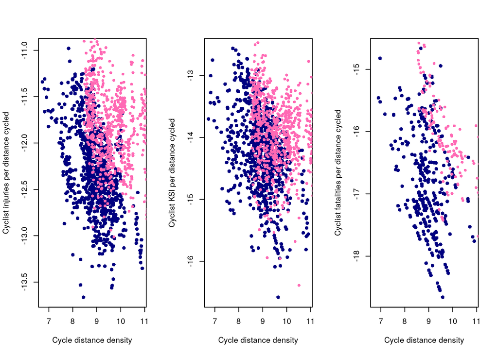

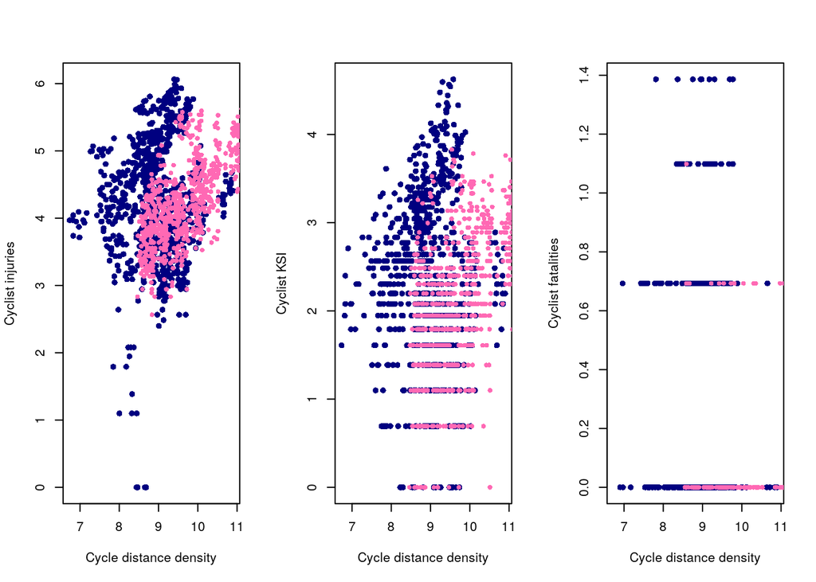